# IODS course project

# Logistic Regression / Week 3

This week we are doing logistic regression with a dataset that has information about portuquese sudents’ school performance. The dataset has the following columns:

```
##  [1] "school"     "sex"        "age"        "address"    "famsize"
##  [6] "Pstatus"    "Medu"       "Fedu"       "Mjob"       "Fjob"
## [11] "reason"     "nursery"    "internet"   "guardian"   "traveltime"
## [16] "studytime"  "failures"   "schoolsup"  "famsup"     "paid"
## [21] "activities" "higher"     "romantic"   "famrel"     "freetime"
## [26] "goout"      "Dalc"       "Walc"       "health"     "absences"
## [31] "G1"         "G2"         "G3"         "alc_use"    "high_use"
```

The data is a mean of two questionaires that contain the students’ performance in maths and portuquese classes. Alc_use is the average of alcohol use during week days and weekends, and high_use was defined as alc_use>2. For more information about the original datasets, see P. Cortez and A. Silva (2008)

Our aim with this dataset is to study the relationship between some of the variables and alchol consumption. Let’s hypothesize that the following variables have the following correlations with alcohol consumption:

- famrel [quality of family relationships (numeric: from 1 - very bad to 5 - excellent)] : better relationships predict smaller alcohol consumption
- Fedu [father’s education (numeric: 0 - none, 1 - primary education (4th grade), 2 - 5th to 9th grade, 3 - secondary education or 4 - higher education)]: high education predicts smaller alcohol consumption
- sex [student’s sex (binary: ‘F’ - female or ‘M’ - male)]: males have a higher alcohol consumption than females
- absences [number of school absences (numeric: from 0 to 93)]: high number of absences correlate high alchohol use
- G3 [final grade (numeric: from 0 to 20, output target)]: bad grades correlate with high alcohol consumption

Let’s start by studying the distribution of these variables:

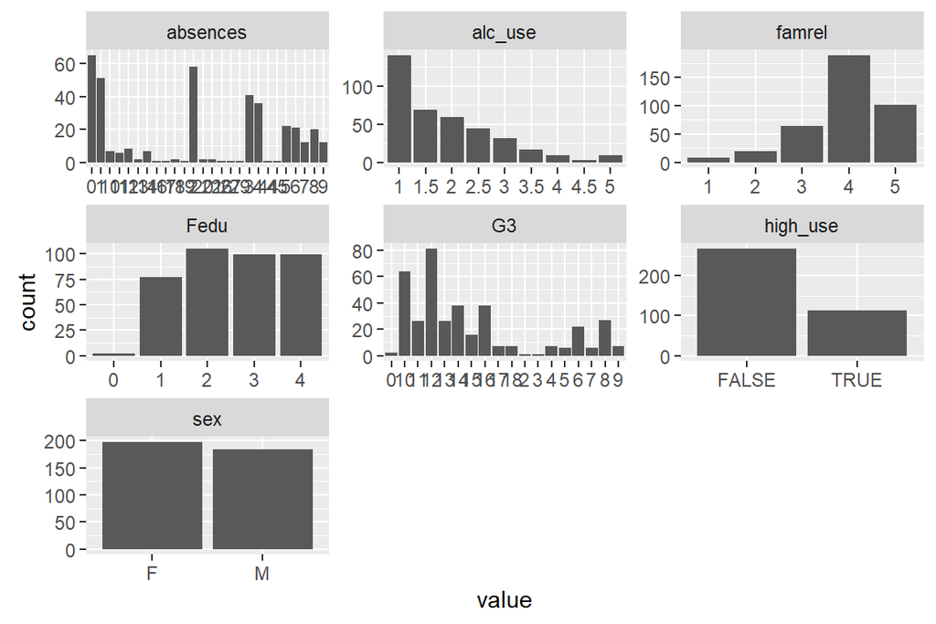

Let’s see some summary statistics

```
## Source: local data frame [4 x 7]
## Groups: sex [?]
##
##      sex high_use count mean_grade mean_absences mean_Fedu mean_famrel
##   (fctr)    (lgl) (int)      (dbl)         (dbl)     (dbl)       (dbl)
## 1      F    FALSE   156   11.39744      4.224359  2.487179    3.910256
## 2      F     TRUE    42   11.71429      6.785714  2.619048    3.761905
## 3      M    FALSE   112   12.20536      2.982143  2.633929    4.133929
## 4      M     TRUE    72   10.27778      6.125000  2.597222    3.791667
```

We can get a better understand of the variances and differences between genders by drawing boxplots

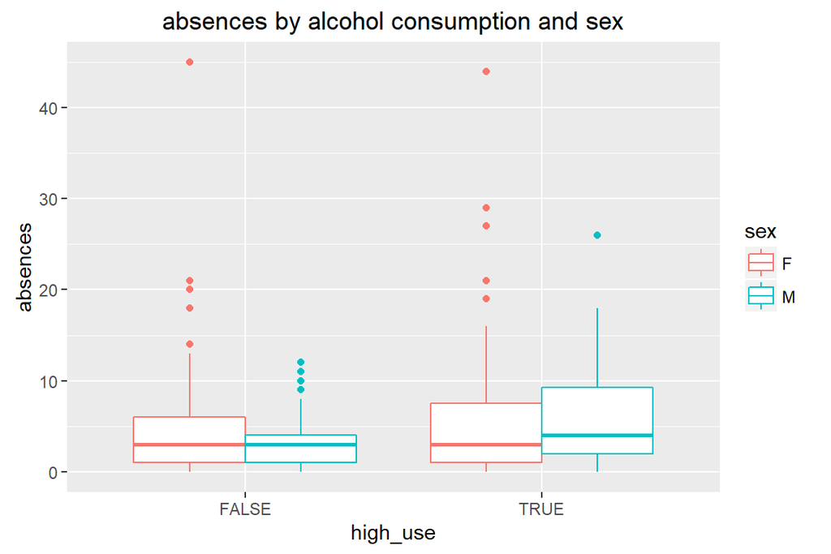

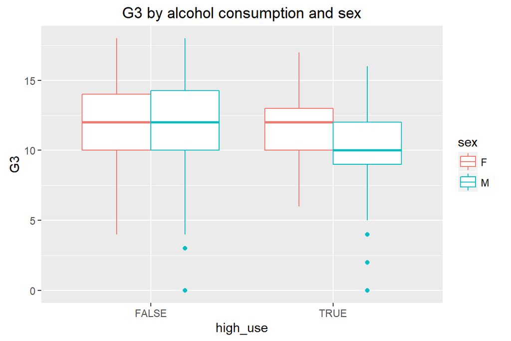

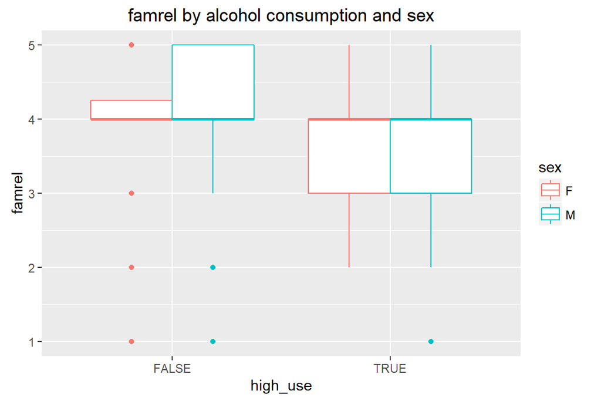

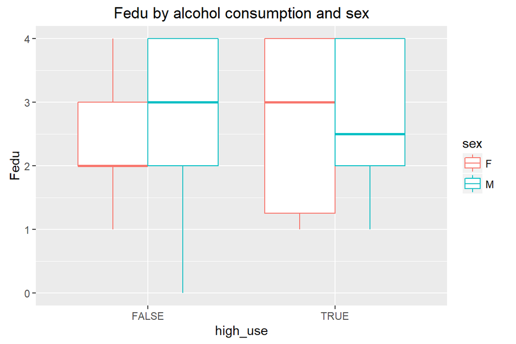

From the above visualizations we can make the following interpretations:

1. the final grades in males seem to have a relationship with alcohol consumption
2. It’s not evident from the boxplots (bad scaling), but according to summary statistics, also absences seem to have a positive correlation with alcohol consumption in both genders
3. Alcohol consumption is higher in males than in females
4. famrel might have slight anti-correlation with alcohol consumption
5. father’s education doesn’t affect alcohol consumption

## Logistic regression

```
FALSE
FALSE Call:
FALSE glm(formula = high_use ~ Fedu + famrel + G3 + absences + sex,
FALSE     family = "binomial", data = interesting)
FALSE
FALSE Deviance Residuals:
FALSE     Min       1Q   Median       3Q      Max
FALSE -2.1519  -0.8117  -0.6134   1.0133   2.2671
FALSE
FALSE Coefficients:
FALSE             Estimate Std. Error z value Pr(>|z|)
FALSE (Intercept) -0.02660    0.68280  -0.039   0.9689
FALSE Fedu         0.06344    0.11168   0.568   0.5700
FALSE famrel      -0.28122    0.12803  -2.197   0.0281 *
FALSE G3          -0.07714    0.03671  -2.102   0.0356 *
FALSE absences     0.08905    0.02263   3.935 8.31e-05 ***
FALSE sexM         1.02560    0.24488   4.188 2.81e-05 ***
FALSE ---
FALSE Signif. codes:  0 '***' 0.001 '**' 0.01 '*' 0.05 '.' 0.1 ' ' 1
FALSE
FALSE (Dispersion parameter for binomial family taken to be 1)
FALSE
FALSE     Null deviance: 465.68  on 381  degrees of freedom
FALSE Residual deviance: 420.38  on 376  degrees of freedom
FALSE AIC: 432.38
FALSE
FALSE Number of Fisher Scoring iterations: 4
```

```
FALSE Waiting for profiling to be done...
```

```
FALSE                    OR     2.5 %    97.5 %
FALSE (Intercept) 0.9737465 0.2528565 3.7149161
FALSE Fedu        1.0655004 0.8563864 1.3281038
FALSE famrel      0.7548620 0.5861940 0.9701893
FALSE G3          0.9257579 0.8607999 0.9944720
FALSE absences    1.0931363 1.0477981 1.1452972
FALSE sexM        2.7887688 1.7369999 4.5452140
```

Interpretation of results:

1. According to the ods ratios and their confidence intervals, students with good familyrelationships are less likely to have high alcohol consumption
2. Students with good grades are also slightly less likely to use high amounts of alcohol
3. high number of absences predicts slighthy higher probability for high alcohol consumption
4. males are more likely to have higher consumption than females

## Predicting alcohol consumption with our model

```
##         prediction
## high_use FALSE TRUE
##    FALSE   253   15
##    TRUE     81   33
```

```
##         prediction
## high_use      FALSE       TRUE        Sum
##    FALSE 0.66230366 0.03926702 0.70157068
##    TRUE  0.21204188 0.08638743 0.29842932
##    Sum   0.87434555 0.12565445 1.00000000
```

From the tables above we see that our model predicted quite well the cases where high_use was false (only 4 prosent were false positives). True cases were not predicted as effectively (20% were missed trues). The total training error is around 25%, so 75% of the cases were predicted correctly.

## References

P. Cortez and A. Silva. Using Data Mining to Predict Secondary School Student Performance. In A. Brito and J. Teixeira Eds., Proceedings of 5th FUture BUsiness TEChnology Conference (FUBUTEC 2008) pp. 5-12, Porto, Portugal, April, 2008, EUROSIS, ISBN 978-9077381-39-7

# Clustering and classification / week 4

This week were using a dataset called ‘Boston’ from the MASS R package. ‘Boston’ Has the housing values of Boston suburbs, including 14 variables that describe the value of the apartments and the socioeconomical status of the area, such as rate of criminality, per capita crime rate by tow, taxes and pupil-teacher rate per town. There are 506 rows in the dataset. The values are numerical, some of them being integers. More detailed description of the varibales can be found in the [R documentation](https://stat.ethz.ch/R-manual/R-devel/library/MASS/html/Boston.html).

## Boston dataset summary

```
## 'data.frame':    506 obs. of  14 variables:
##  $ crim   : num  0.00632 0.02731 0.02729 0.03237 0.06905 ...
##  $ zn     : num  18 0 0 0 0 0 12.5 12.5 12.5 12.5 ...
##  $ indus  : num  2.31 7.07 7.07 2.18 2.18 2.18 7.87 7.87 7.87 7.87 ...
##  $ chas   : int  0 0 0 0 0 0 0 0 0 0 ...
##  $ nox    : num  0.538 0.469 0.469 0.458 0.458 0.458 0.524 0.524 0.524 0.524 ...
##  $ rm     : num  6.58 6.42 7.18 7 7.15 ...
##  $ age    : num  65.2 78.9 61.1 45.8 54.2 58.7 66.6 96.1 100 85.9 ...
##  $ dis    : num  4.09 4.97 4.97 6.06 6.06 ...
##  $ rad    : int  1 2 2 3 3 3 5 5 5 5 ...
##  $ tax    : num  296 242 242 222 222 222 311 311 311 311 ...
##  $ ptratio: num  15.3 17.8 17.8 18.7 18.7 18.7 15.2 15.2 15.2 15.2 ...
##  $ black  : num  397 397 393 395 397 ...
##  $ lstat  : num  4.98 9.14 4.03 2.94 5.33 ...
##  $ medv   : num  24 21.6 34.7 33.4 36.2 28.7 22.9 27.1 16.5 18.9 ...
```

```
##       crim                zn             indus            chas
##  Min.   : 0.00632   Min.   :  0.00   Min.   : 0.46   Min.   :0.00000
##  1st Qu.: 0.08204   1st Qu.:  0.00   1st Qu.: 5.19   1st Qu.:0.00000
##  Median : 0.25651   Median :  0.00   Median : 9.69   Median :0.00000
##  Mean   : 3.61352   Mean   : 11.36   Mean   :11.14   Mean   :0.06917
##  3rd Qu.: 3.67708   3rd Qu.: 12.50   3rd Qu.:18.10   3rd Qu.:0.00000
##  Max.   :88.97620   Max.   :100.00   Max.   :27.74   Max.   :1.00000
##       nox               rm             age              dis
##  Min.   :0.3850   Min.   :3.561   Min.   :  2.90   Min.   : 1.130
##  1st Qu.:0.4490   1st Qu.:5.886   1st Qu.: 45.02   1st Qu.: 2.100
##  Median :0.5380   Median :6.208   Median : 77.50   Median : 3.207
##  Mean   :0.5547   Mean   :6.285   Mean   : 68.57   Mean   : 3.795
##  3rd Qu.:0.6240   3rd Qu.:6.623   3rd Qu.: 94.08   3rd Qu.: 5.188
##  Max.   :0.8710   Max.   :8.780   Max.   :100.00   Max.   :12.127
##       rad              tax           ptratio          black
##  Min.   : 1.000   Min.   :187.0   Min.   :12.60   Min.   :  0.32
##  1st Qu.: 4.000   1st Qu.:279.0   1st Qu.:17.40   1st Qu.:375.38
##  Median : 5.000   Median :330.0   Median :19.05   Median :391.44
##  Mean   : 9.549   Mean   :408.2   Mean   :18.46   Mean   :356.67
##  3rd Qu.:24.000   3rd Qu.:666.0   3rd Qu.:20.20   3rd Qu.:396.23
##  Max.   :24.000   Max.   :711.0   Max.   :22.00   Max.   :396.90
##      lstat            medv
##  Min.   : 1.73   Min.   : 5.00
##  1st Qu.: 6.95   1st Qu.:17.02
##  Median :11.36   Median :21.20
##  Mean   :12.65   Mean   :22.53
##  3rd Qu.:16.95   3rd Qu.:25.00
##  Max.   :37.97   Max.   :50.00
```

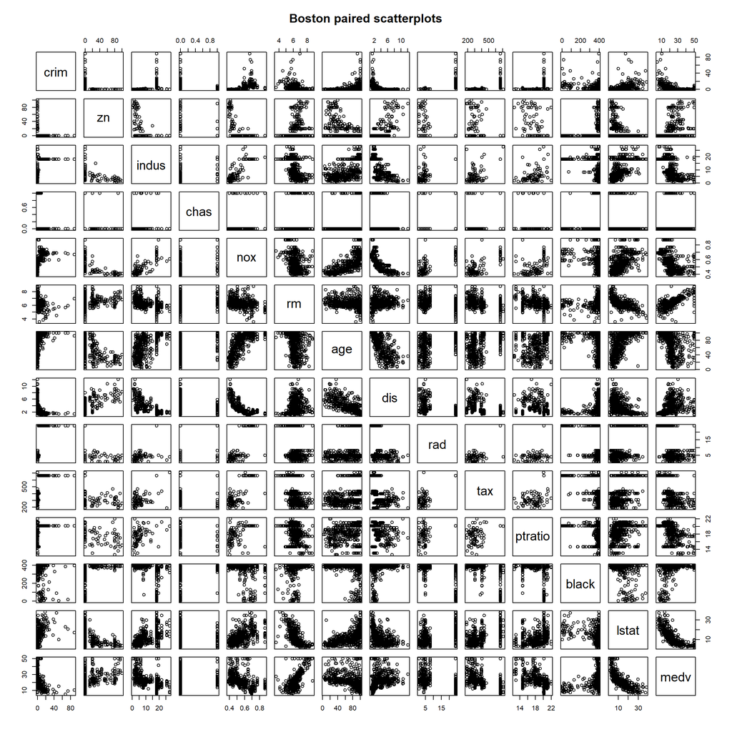

## Scaled data

```
##       crim                 zn               indus
##  Min.   :-0.419367   Min.   :-0.48724   Min.   :-1.5563
##  1st Qu.:-0.410563   1st Qu.:-0.48724   1st Qu.:-0.8668
##  Median :-0.390280   Median :-0.48724   Median :-0.2109
##  Mean   : 0.000000   Mean   : 0.00000   Mean   : 0.0000
##  3rd Qu.: 0.007389   3rd Qu.: 0.04872   3rd Qu.: 1.0150
##  Max.   : 9.924110   Max.   : 3.80047   Max.   : 2.4202
##       chas              nox                rm               age
##  Min.   :-0.2723   Min.   :-1.4644   Min.   :-3.8764   Min.   :-2.3331
##  1st Qu.:-0.2723   1st Qu.:-0.9121   1st Qu.:-0.5681   1st Qu.:-0.8366
##  Median :-0.2723   Median :-0.1441   Median :-0.1084   Median : 0.3171
##  Mean   : 0.0000   Mean   : 0.0000   Mean   : 0.0000   Mean   : 0.0000
##  3rd Qu.:-0.2723   3rd Qu.: 0.5981   3rd Qu.: 0.4823   3rd Qu.: 0.9059
##  Max.   : 3.6648   Max.   : 2.7296   Max.   : 3.5515   Max.   : 1.1164
##       dis               rad               tax             ptratio
##  Min.   :-1.2658   Min.   :-0.9819   Min.   :-1.3127   Min.   :-2.7047
##  1st Qu.:-0.8049   1st Qu.:-0.6373   1st Qu.:-0.7668   1st Qu.:-0.4876
##  Median :-0.2790   Median :-0.5225   Median :-0.4642   Median : 0.2746
##  Mean   : 0.0000   Mean   : 0.0000   Mean   : 0.0000   Mean   : 0.0000
##  3rd Qu.: 0.6617   3rd Qu.: 1.6596   3rd Qu.: 1.5294   3rd Qu.: 0.8058
##  Max.   : 3.9566   Max.   : 1.6596   Max.   : 1.7964   Max.   : 1.6372
##      black             lstat              medv
##  Min.   :-3.9033   Min.   :-1.5296   Min.   :-1.9063
##  1st Qu.: 0.2049   1st Qu.:-0.7986   1st Qu.:-0.5989
##  Median : 0.3808   Median :-0.1811   Median :-0.1449
##  Mean   : 0.0000   Mean   : 0.0000   Mean   : 0.0000
##  3rd Qu.: 0.4332   3rd Qu.: 0.6024   3rd Qu.: 0.2683
##  Max.   : 0.4406   Max.   : 3.5453   Max.   : 2.9865
```

We can see that after scaling, the mean is 0 for each variable, and that variables below the mean have negative values and variables above mean have positive values. The scaling of the data makes the different variables comparable.

Next we want to make a model that predicts the criminality in certain areas based on the other variables. For this purpose we first replace the ‘crime’ variable with a factorized variable, that we want to predict eventually. The break points for the crime variable are set to the quantiles and the classes are named as ‘high’, ‘med_high’, ‘med_low’ and ‘low’.

We also need to divide the data into a training and test sets, so that we can use part of the data to train our model, and then test the validity of the model with the test data. 80% of the data is randomly assigned to training set and the rest of the data is used for testing.

## Linear discriminant analysis and LDA biplot

```
## Call:
## lda(crime ~ ., data = train)
##
## Prior probabilities of groups:
##       low   med_low  med_high      high
## 0.2450495 0.2623762 0.2500000 0.2425743
##
## Group means:
##                   zn      indus         chas        nox          rm
## low       0.96040455 -0.9807651 -0.192791689 -0.9165805  0.40151751
## med_low  -0.08557041 -0.3397819 -0.049474337 -0.5997522 -0.14393954
## med_high -0.39384444  0.1835419  0.117482837  0.3695258  0.04180871
## high     -0.48724019  1.0171960  0.008892378  1.0353885 -0.35125481
##                 age        dis        rad        tax     ptratio
## low      -0.9253528  0.9636634 -0.6814137 -0.7690347 -0.41337185
## med_low  -0.3558036  0.4147925 -0.5495709 -0.5348544 -0.05092534
## med_high  0.4260007 -0.3982829 -0.4110490 -0.3155254 -0.28678788
## high      0.8448015 -0.8643358  1.6373367  1.5134896  0.77985517
##                black       lstat         medv
## low       0.38025205 -0.78991632  0.451560863
## med_low   0.32680987 -0.14569567 -0.003259302
## med_high  0.08583359  0.06175499  0.149838988
## high     -0.77962732  0.82552153 -0.630649953
##
## Coefficients of linear discriminants:
##                 LD1         LD2        LD3
## zn       0.08275968  0.61653030 -0.9458263
## indus    0.08735059 -0.47986220  0.4070649
## chas    -0.06939461 -0.05927600  0.1450911
## nox      0.35695935 -0.59393175 -1.3694019
## rm      -0.08159705 -0.07160470 -0.1223628
## age      0.24781870 -0.29571089 -0.1094091
## dis     -0.09686849 -0.10162633  0.2741295
## rad      3.11260319  0.84894309  0.1534899
## tax     -0.01345098  0.26702943  0.3006008
## ptratio  0.09318045  0.03453744 -0.2134307
## black   -0.14603850  0.02912687  0.1221387
## lstat    0.23203664 -0.25239586  0.3646203
## medv     0.16293818 -0.37944494 -0.1920512
##
## Proportion of trace:
##    LD1    LD2    LD3
## 0.9424 0.0449 0.0127
```

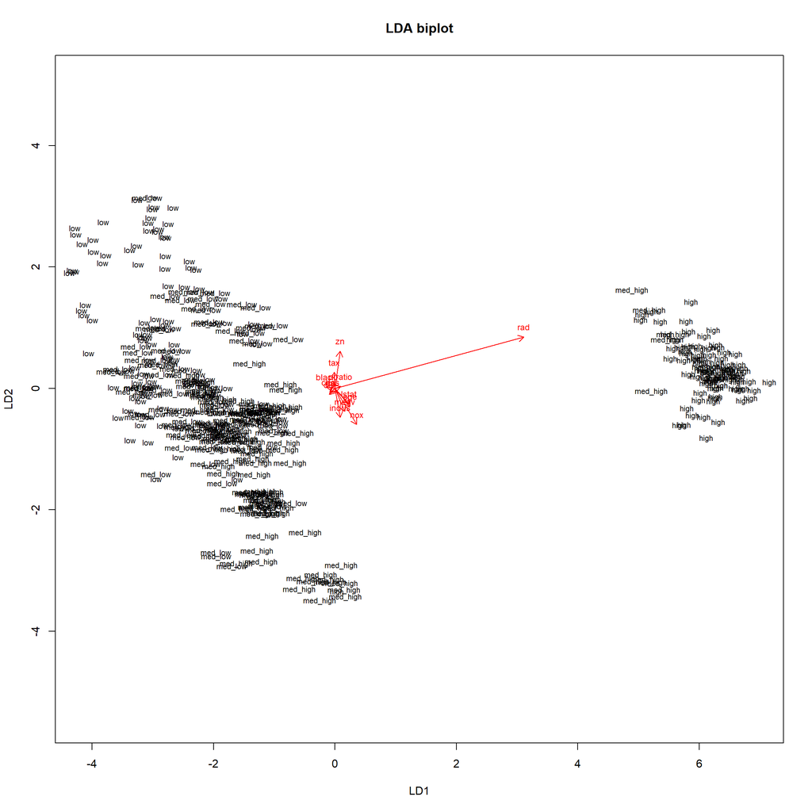

## Using the model to predict criminality classes in the test dataset

```
##           predicted
## correct    low med_low med_high high
##   low       12      12        4    0
##   med_low    4       9        7    0
##   med_high   0       8       16    1
##   high       0       0        0   29
```

From the plot above we can see that areas with high criminality rate form their own cluster, and other classes are closer to each other. The main variable that sets high criminality areas apart from the others is ‘rad’(index of accessibility to radial highways). The suburbs that have good access to radial high ways seem to have high criminality rate.

## K-means clustering

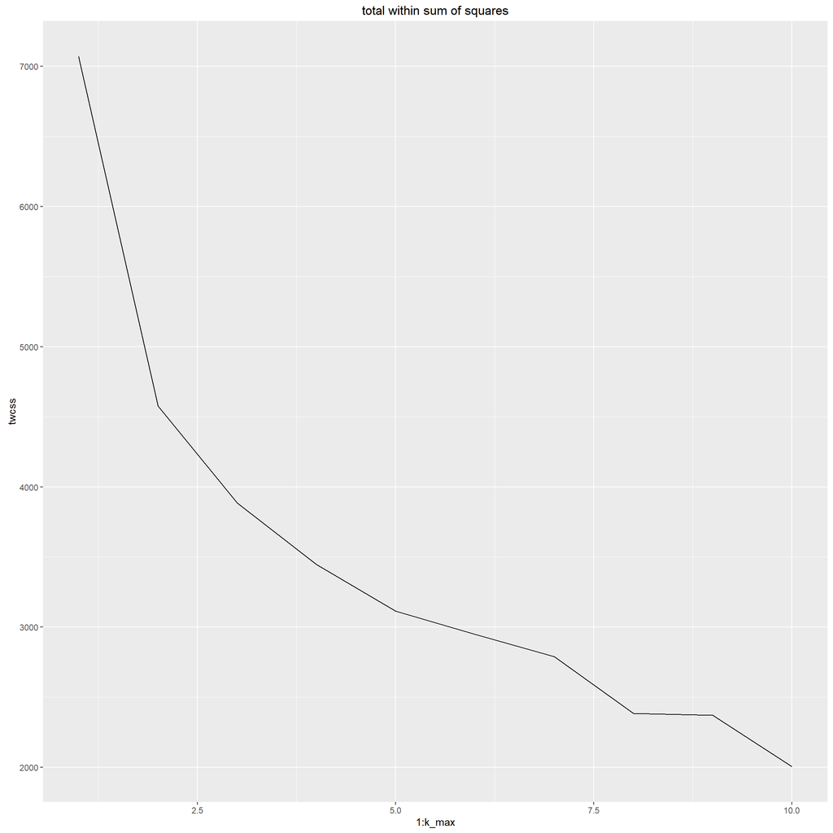

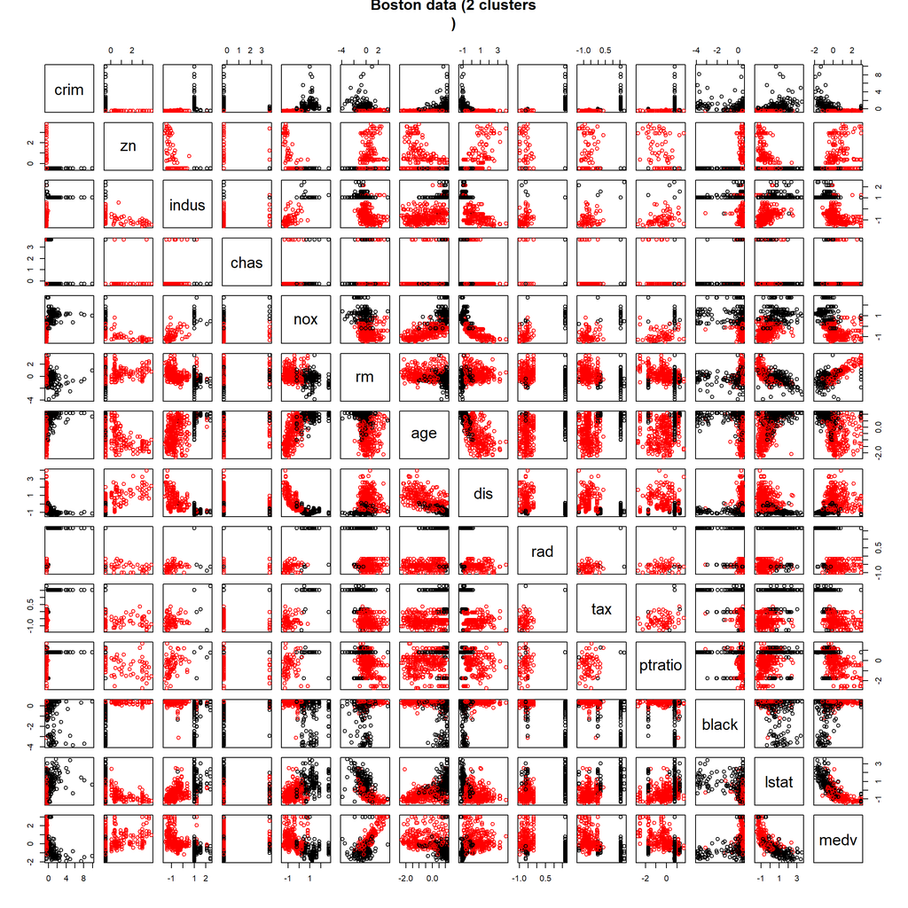

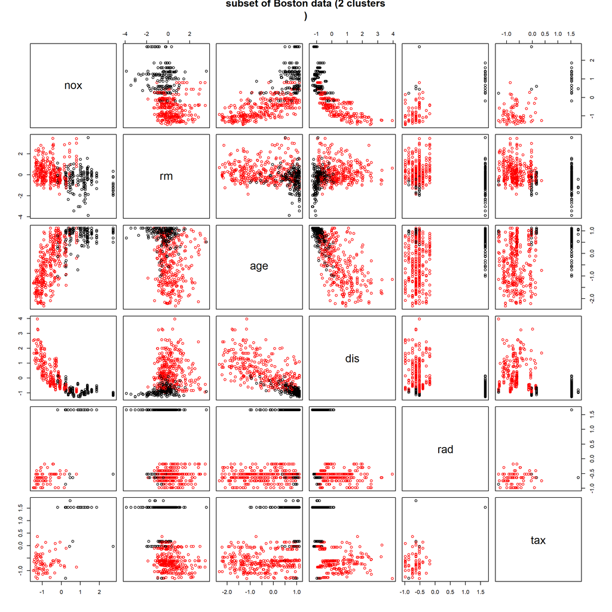

Here we did K-means clustering based on euclidean distances. The optimal number of clusters was chosen by finding the point where the total within sum of squares had a great drop. Based on this method, the optimal number of clusters is 2. From the graphs we can see that these two clusters deviate from each other mainly in the ‘rad’ and ‘tax’ variables, but the clusters can also be seen in other variables where the differences are more continuous (such as age, rm and nox).

# Dimensionality reduction techniques / Week 5

This week were are using dimensionality reduction techniques for studying both numerical and categorical datasets. We will start by studying the ‘human’ dataset, which is a combination of two datasets, human_developemnt and gender_inenquality, which originate from the United Nations Development Programme. More info about the datasets can be found [here](http://hdr.undp.org/en/content/human-development-index-hdi).

The data consists of 195 countries and 19 variables that describe the countries’ human development index and gender inequality. In addition to the original variables, we have also added two variables, edu2_sex=sec_edu_f/sec_edu_m, labour_sex=labour_f/labour_m, which describe the ratio between gender specific education and labour scores.

```
FALSE     Edu2.FM          Labo.FM          Edu.Exp         Life.Exp
FALSE  Min.   :0.1717   Min.   :0.1857   Min.   : 7.00   Min.   :49.00
FALSE  1st Qu.:0.7427   1st Qu.:0.6005   1st Qu.:11.30   1st Qu.:66.42
FALSE  Median :0.9402   Median :0.7576   Median :13.50   Median :74.20
FALSE  Mean   :0.8564   Mean   :0.7091   Mean   :13.23   Mean   :71.72
FALSE  3rd Qu.:0.9968   3rd Qu.:0.8538   3rd Qu.:15.20   3rd Qu.:77.28
FALSE  Max.   :1.4967   Max.   :1.0380   Max.   :20.20   Max.   :83.50
FALSE       GNI            Mat.Mor          Ado.Birth         Parli.F
FALSE  Min.   :  2.00   Min.   :   1.00   Min.   :  0.60   Min.   : 0.00
FALSE  1st Qu.: 53.25   1st Qu.:  11.25   1st Qu.: 12.62   1st Qu.:12.40
FALSE  Median : 98.50   Median :  49.00   Median : 33.20   Median :19.35
FALSE  Mean   : 98.11   Mean   : 145.96   Mean   : 46.14   Mean   :20.96
FALSE  3rd Qu.:142.75   3rd Qu.: 190.00   3rd Qu.: 71.78   3rd Qu.:28.07
FALSE  Max.   :192.00   Max.   :1100.00   Max.   :175.60   Max.   :57.50
```

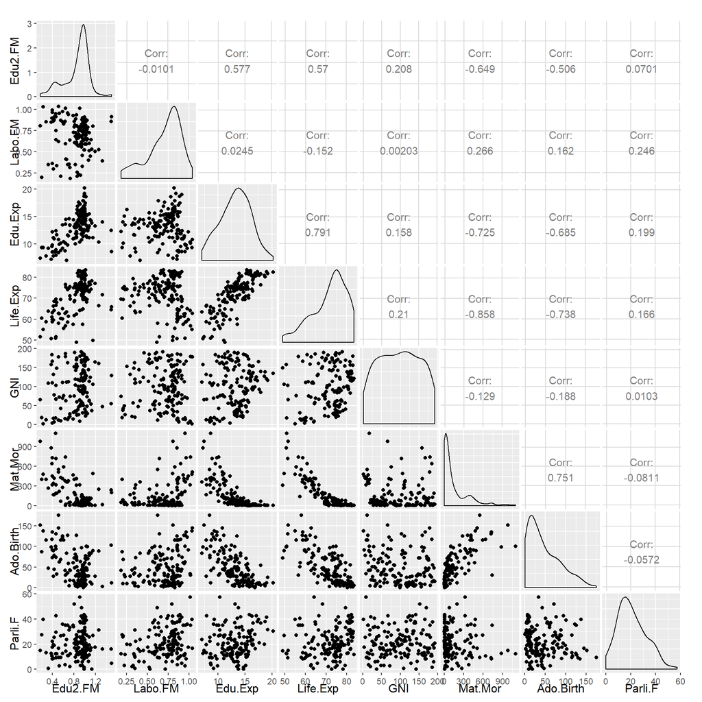

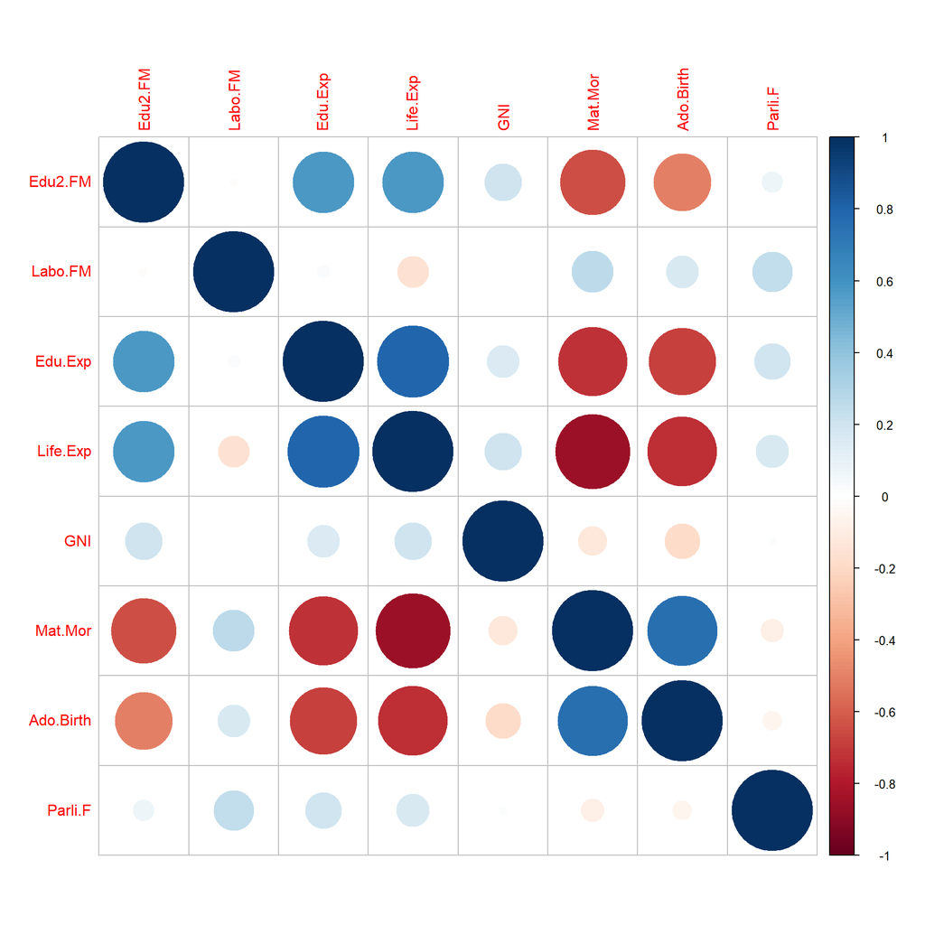

From the correlation matrix we can see that maternal mortality is strongly correlated with adolescent birthrate. They are both anticorrelated with education and life expectancy (which correlate with each other). Femala/male ratio in education correlates with education and life expectancy, and anticorrelates with maternal mortality and adoslectent birth rate.

## Principal component analysis

We will now use a method called principal component analysis for reducing the number of variables in the data. PCA will reduce the dimensionality of the data by creating principal components that explain the different dimensions of variability in the data. PCA1 explains most of the variability, PCA2 the second most and so on. Let’s use bipolots for visualizing the components, we are doing this first without scaling the data and then with the scaled data:

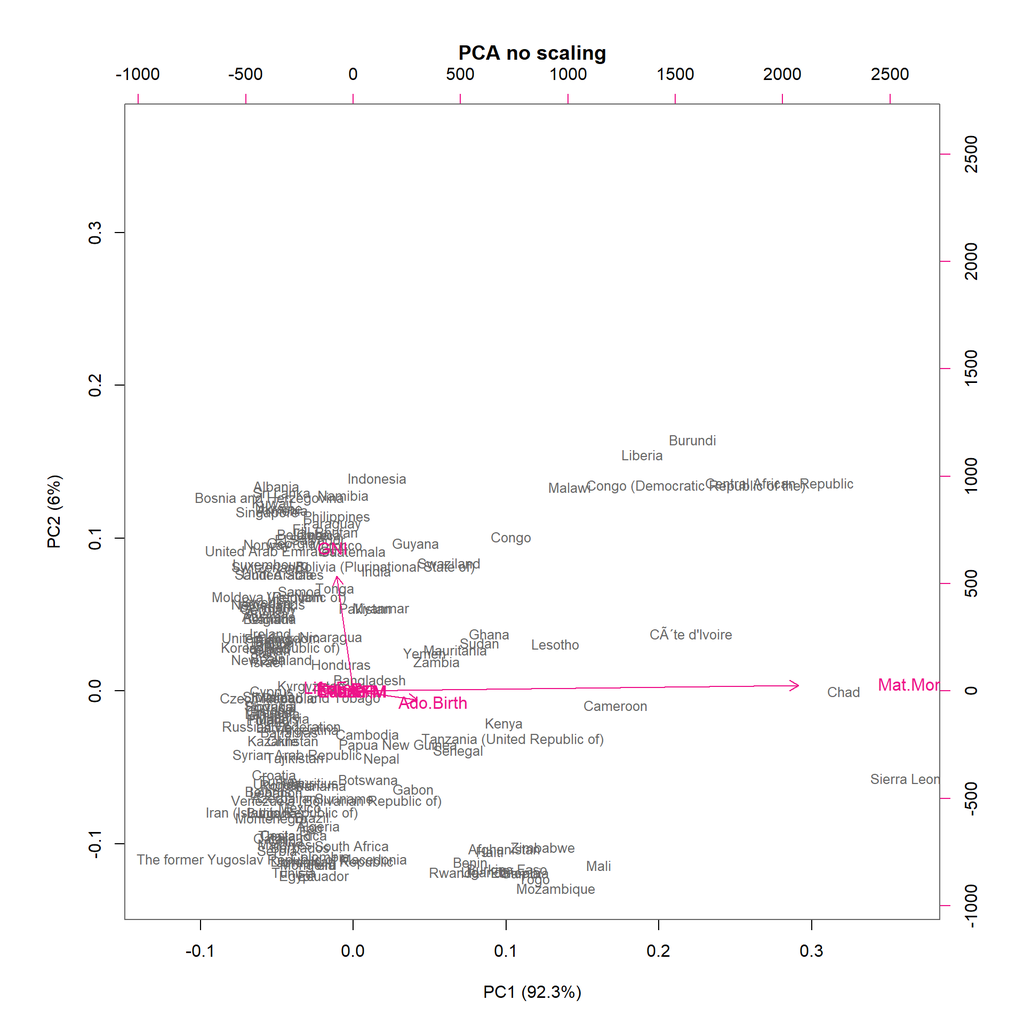

From the plot above we can see that in the non-standardized data, maternal mortality seems to explain most of the variability in the data. It is strongly correlated with PC1 which explains 92% of the variance in the data. PCA2 only explains 6% of the variance and is mostly correlated wiht GNI. We can predict that these results are highly affected by the difference in the variance of the non-standardized variables. Maternal mortality ranges from 1 to 1100, so it has clearly higher variance than the other variables, and hence it of course explains most of the variance in the data.

Let’s now standardize the data and do the PCA again.

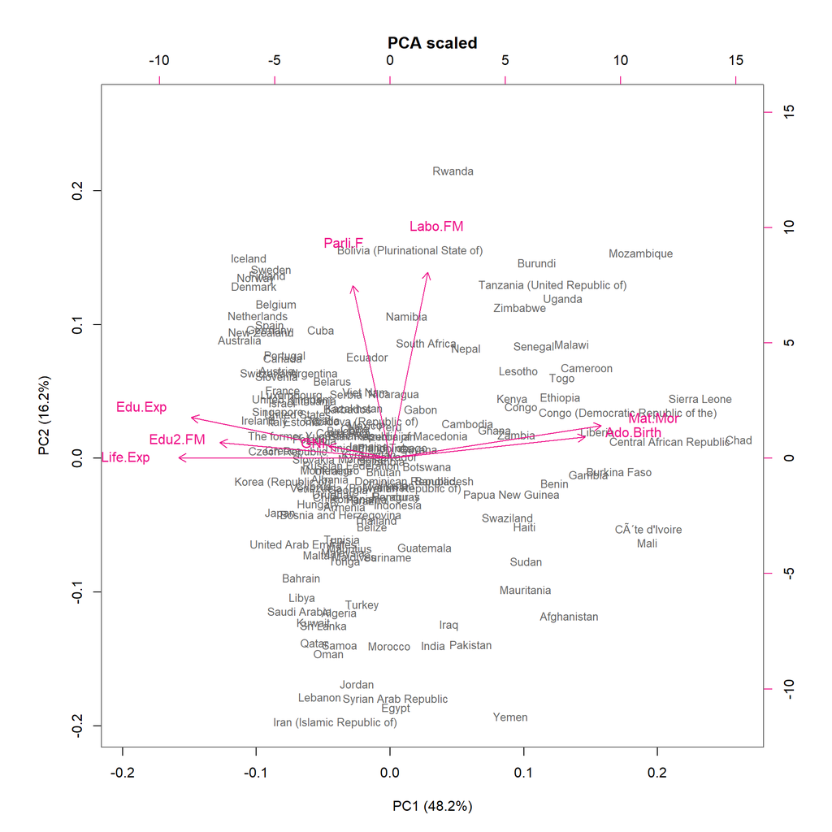

After standardization we can see that the variance in the data is actually explained by other factors as well. PC1 explains almost half of the variance in the data, and it is formed by life expectancy, education ratio between the genders, and education expectancy, maternal mortality, and birthrate. Hence we can say that education in general explains most of the variance in the data. Education is likely to also decrease the maternal mortality and birthrate.

PC2 explains 16% of the variance, and it is formed by female participation in the parliament and gender ratio in the labour. This component mainly reflects the equality of women and men in the society, and the chances of women to participate in decision making.

## MCA with categorical variables (Tea dataset)

Let’s now explore a categorical data set. We are using ‘tea’ data set as an example. Tea is included in the FactoMineR package and more information about it can be found [here](https://rdrr.io/cran/FactoMineR/man/tea.html).

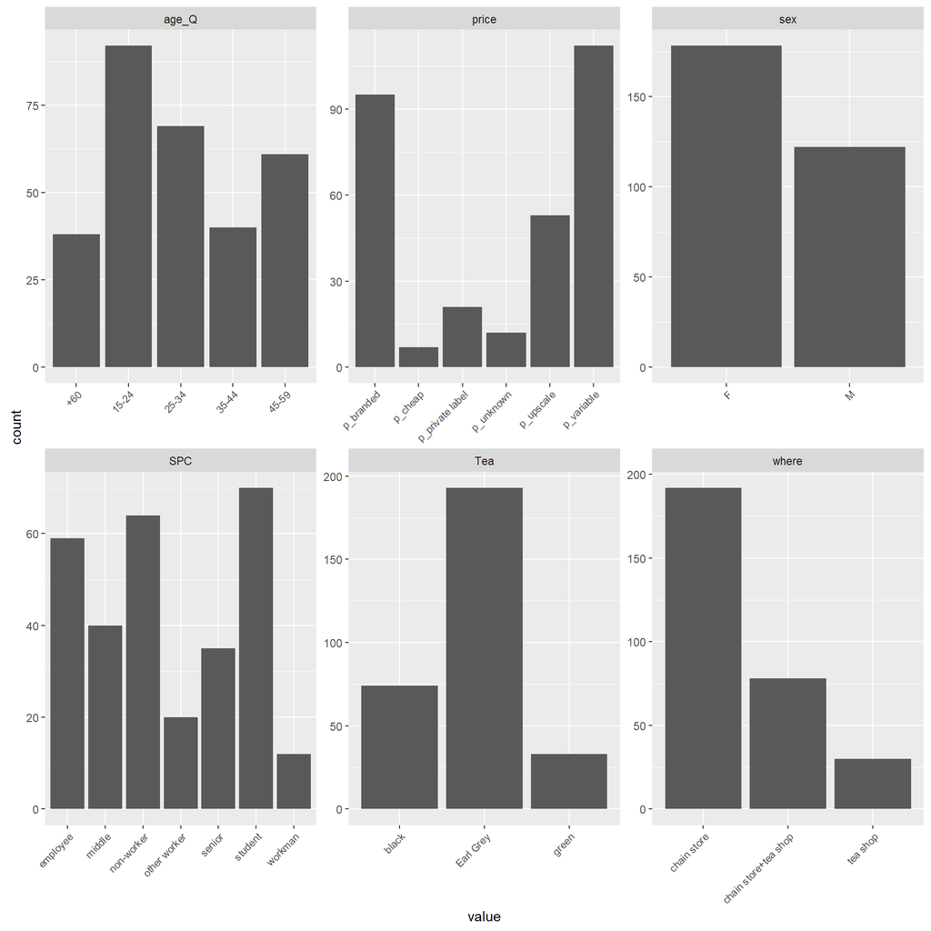

We now have a dataset with 6 categorical variables that describe the different aspects of tea consumption. There are 300 observations. Let’s now do MCA for the dataset. MCA corresponds PCA but it can be used factorized variables.

```
##
## Call:
## MCA(X = tea_time, graph = FALSE)
##
##
## Eigenvalues
##                        Dim.1   Dim.2   Dim.3   Dim.4   Dim.5   Dim.6
## Variance               0.373   0.299   0.244   0.229   0.205   0.194
## % of var.             11.194   8.973   7.320   6.874   6.164   5.809
## Cumulative % of var.  11.194  20.167  27.487  34.360  40.524  46.334
##                        Dim.7   Dim.8   Dim.9  Dim.10  Dim.11  Dim.12
## Variance               0.192   0.177   0.174   0.172   0.166   0.156
## % of var.              5.758   5.320   5.230   5.173   4.966   4.683
## Cumulative % of var.  52.092  57.412  62.642  67.815  72.781  77.464
##                       Dim.13  Dim.14  Dim.15  Dim.16  Dim.17  Dim.18
## Variance               0.141   0.121   0.119   0.112   0.095   0.065
## % of var.              4.235   3.621   3.565   3.367   2.848   1.964
## Cumulative % of var.  81.699  85.320  88.885  92.252  95.100  97.064
##                       Dim.19  Dim.20
## Variance               0.052   0.045
## % of var.              1.573   1.363
## Cumulative % of var.  98.637 100.000
##
## Individuals (the 10 first)
##                 Dim.1    ctr   cos2    Dim.2    ctr   cos2    Dim.3    ctr
## 1            |  0.416  0.154  0.025 |  0.852  0.809  0.103 | -0.221  0.067
## 2            |  0.238  0.051  0.021 |  0.157  0.027  0.009 | -0.089  0.011
## 3            | -0.099  0.009  0.003 |  0.296  0.098  0.025 | -0.122  0.020
## 4            | -0.744  0.495  0.339 |  0.031  0.001  0.001 | -0.325  0.144
## 5            | -0.119  0.013  0.007 |  0.394  0.173  0.076 |  0.184  0.046
## 6            | -0.907  0.735  0.231 |  0.087  0.008  0.002 |  0.161  0.035
## 7            |  0.243  0.053  0.019 |  0.631  0.444  0.130 | -0.621  0.528
## 8            |  0.299  0.080  0.028 |  0.210  0.049  0.014 | -0.476  0.310
## 9            |  0.806  0.580  0.165 |  0.518  0.299  0.068 | -0.915  1.144
## 10           |  1.080  1.042  0.268 |  0.414  0.191  0.039 | -0.793  0.859
##                cos2
## 1             0.007 |
## 2             0.003 |
## 3             0.004 |
## 4             0.065 |
```

[output cut: 24 more lines]

```
## M              6.896 |   0.151   0.637   0.016   2.168 |
## employee       2.777 |   0.625   5.244   0.096   5.345 |
## middle         4.740 |  -0.291   0.771   0.013  -1.974 |
## non-worker   -13.001 |   0.279   1.137   0.021   2.515 |
## other worker   3.771 |  -0.025   0.003   0.000  -0.117 |
## senior         5.837 |  -0.614   3.004   0.050  -3.858 |
##
## Categorical variables (eta2)
##                Dim.1 Dim.2 Dim.3
## Tea          | 0.231 0.022 0.266 |
## sex          | 0.092 0.159 0.016 |
## SPC          | 0.578 0.722 0.172 |
## price        | 0.347 0.095 0.424 |
## age_Q        | 0.630 0.713 0.141 |
## where        | 0.362 0.084 0.446 |
```

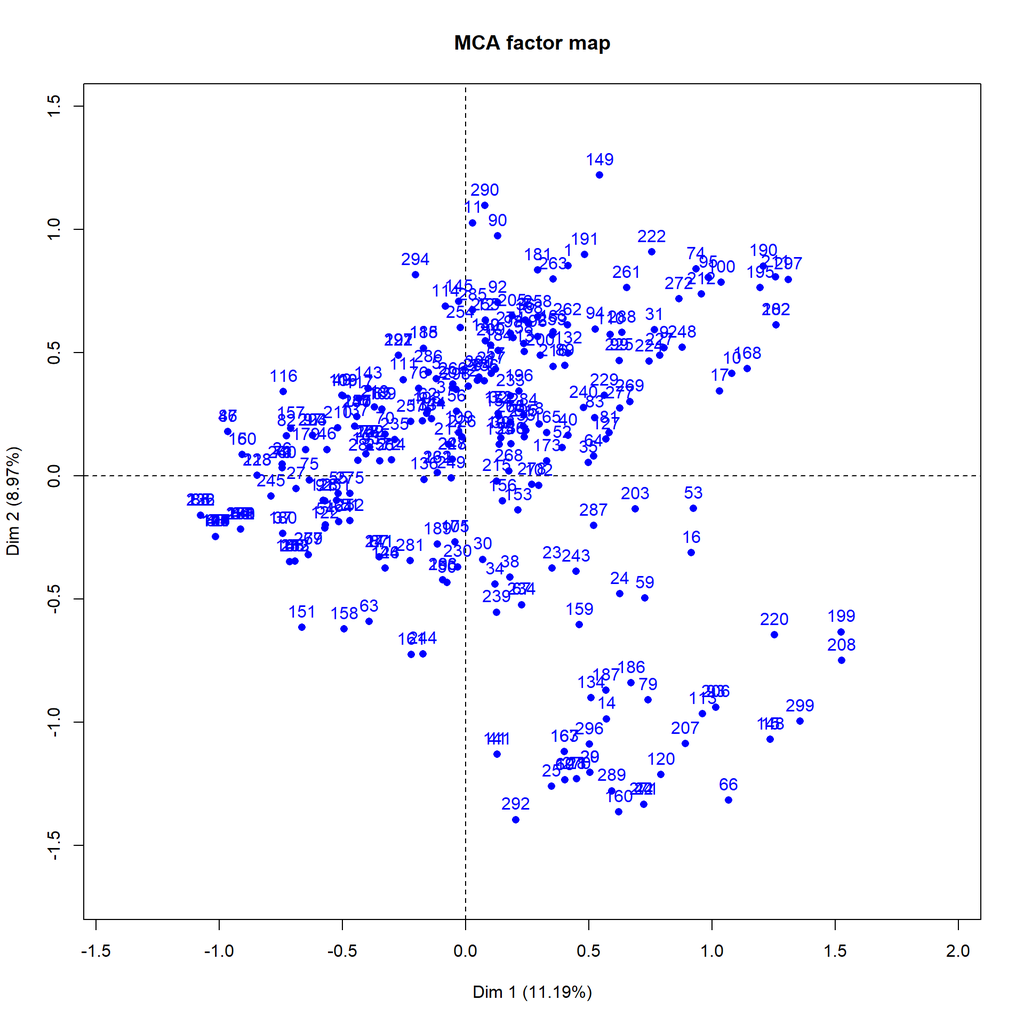

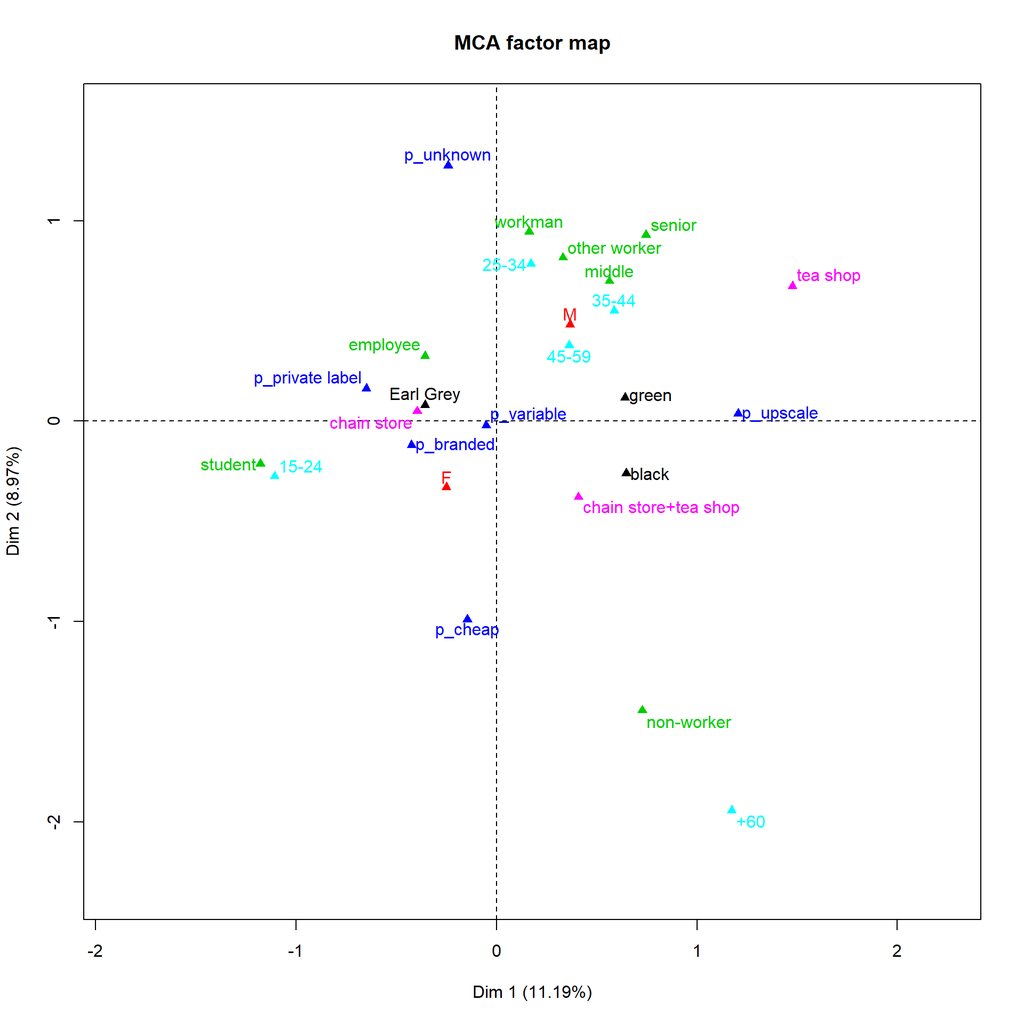

None of the selected varibles seem to explain the variance very clearly, the MCA plot with the variables is quite scattered, no conclusions can be drawn from this data. The +60 age class and non-workers seem to stand out from the rest of the group, but we should probably choose some other variables to explain how they differ from the other consumers.

# Analysis of longitudal data / week 6

## Data analysis of RATS data

We will first analyze data from a nutrition study conducted in three groups of rats (Crowder and Hand, 1990). Groups had different diets and the body weights of each individual was recorded for 9 weeks. We are studying whether the diets had an effect on the growth profiles.

### Individual growth profiles by diet group for the RATS data.

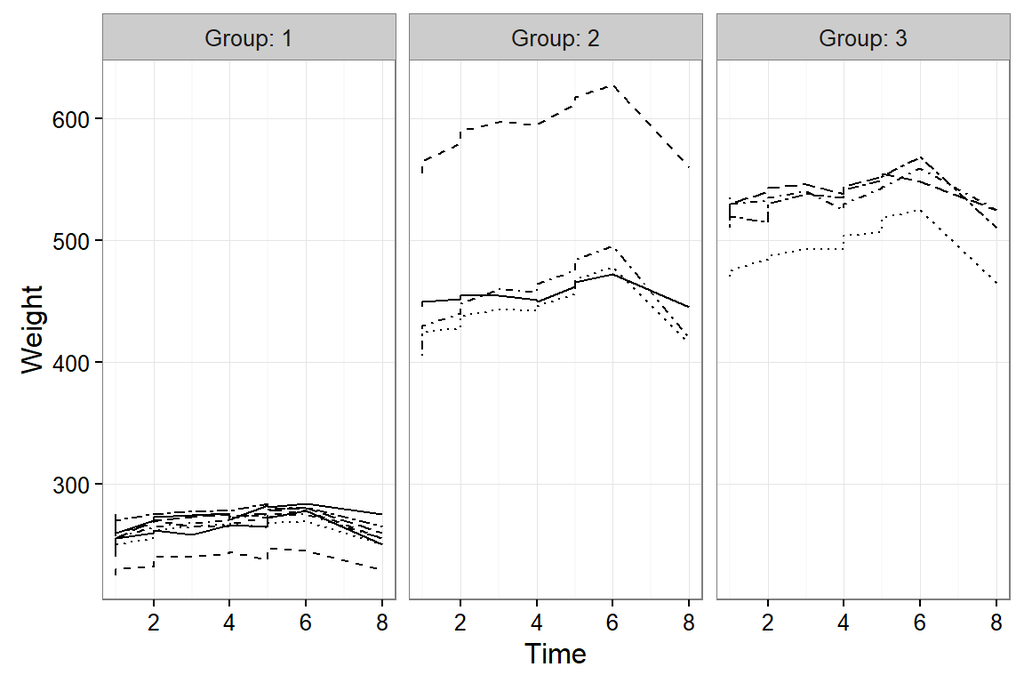

From the above graphs we can see that the profiles look quite similar across the different diets. The weight increases until week 6 and then starts to drop towards the original value. Rats in groups 2 and 3 have higher weights overall compared to group 1. In group 2 there is one individual that is markedly heavier than the others in that group.

### Individual growth profiles by diet group for the RATS data after standardization

[figure not shown]

### Mean weight profiles for the diet groups

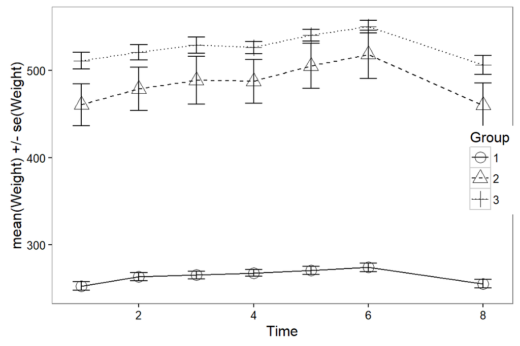

Here we can see the profiles of mean weights in each groups. The mean profiles look quite the same as the individual profiles, and we can see that group 2 means have high standard errors because one rat had markedly higher weight than others in that group.

### Boxplots

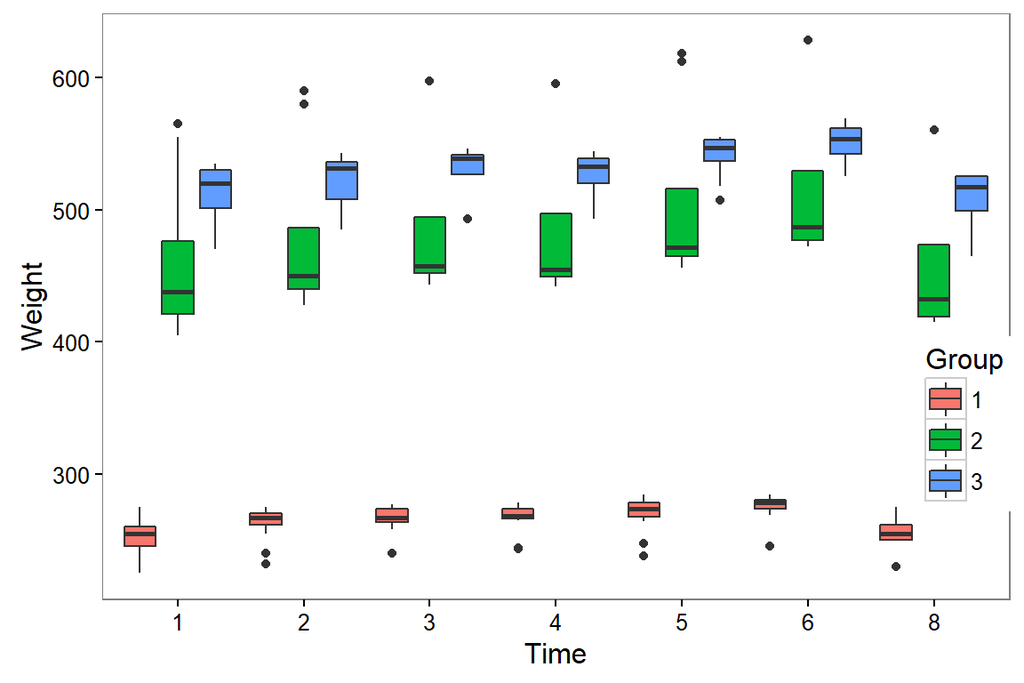

I’m not sure if boxplots are the best method for visualizing data that we have here, because we only have a few subjects per group per timepoint. I find the boxplots a bit misleading, as the quantiles don’t really tell much with such small N’s. But overall we can see the same story as from the previous mean plots.

### Boxplots of mean summary measures

```
## Observations: 16
## Variables: 3
## $ Group (fctr) 1, 1, 1, 1, 1, 1, 1, 1, 2, 2, 2, 2, 3, 3, 3, 3
## $ ID    (fctr) 1, 2, 3, 4, 5, 6, 7, 8, 9, 10, 11, 12, 13, 14, 15, 16
## $ mean  (dbl) 264.1111, 239.8889, 263.0000, 268.5556, 272.6667, 276.88...
```

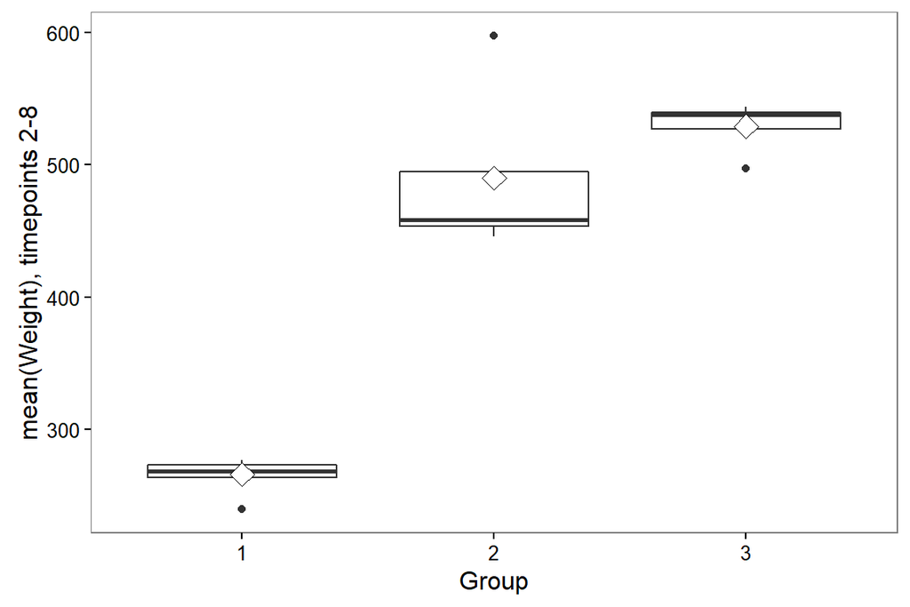

All groups seem to have one outlier. We could remove the outliers, but the individual growth profiles showed that their profiles are actually similar to other individuals in their groups. Also, we are really not interested in the weight difference between the means of the groups accross time, but between the mean weight change of the groups. COnsidering that the groups were really different in the beginning, we don’t get much information from these kind of plots. Let’s however remove the most obvious outlier from group 2 and check what the boxplot looks like.

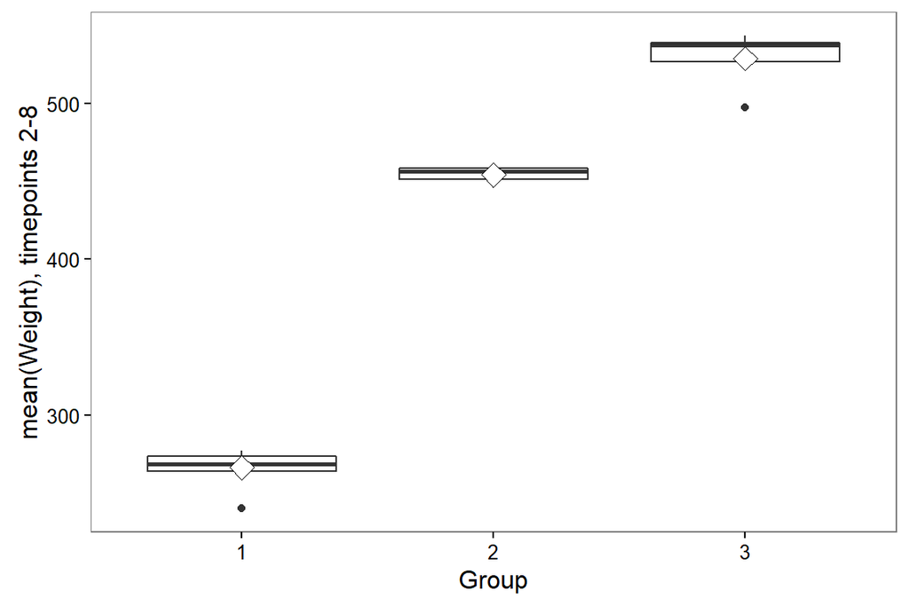

Next in the MABS they performed t-tests for BPRS data. However, unlike in the BPRS data, here we have 3 groups instead of 2. Hence we cannot perform t-tests with the RATS data. We could do t-tests between the different groups and then adjusts the p-values, but we are really not interested in finding out whether there is a difference in the means of the groups, as there was already a difference in the beginning, and this difference doesn’t really tell anything about the effect of the different diets.

### Analysis of covariance

```
##
## Call:
## lm(formula = mean ~ baseline + Group, data = RATS8S2)
##
## Residuals:
##     Min      1Q  Median      3Q     Max
## -25.493  -4.188   2.205   7.448  15.727
##
## Coefficients:
##             Estimate Std. Error t value Pr(>|t|)
## (Intercept) 33.69364   22.81191   1.477   0.1654
## baseline     0.92774    0.08938  10.379 2.39e-07 ***
## Group2      35.40015   19.62787   1.804   0.0964 .
## Group3      23.34671   24.24745   0.963   0.3546
## ---
## Signif. codes:  0 '***' 0.001 '**' 0.01 '*' 0.05 '.' 0.1 ' ' 1
##
## Residual standard error: 12.18 on 12 degrees of freedom
## Multiple R-squared:  0.9931, Adjusted R-squared:  0.9914
## F-statistic: 575.2 on 3 and 12 DF,  p-value: 3.174e-13
```

```
## Analysis of Variance Table
##
## Response: mean
##           Df Sum Sq Mean Sq   F value   Pr(>F)
## baseline   1 254912  254912 1719.1122 2.51e-14 ***
## Group      2    944     472    3.1821  0.07785 .
## Residuals 12   1779     148
## ---
## Signif. codes:  0 '***' 0.001 '**' 0.01 '*' 0.05 '.' 0.1 ' ' 1
```

From the analysis of covariance we can see that there is a diffence in the means of the different groups, but it’s mainly due the difference in the baseline, so we cannot make interpretations about the effect of the diet.

We don’t have any missing values, so we don’t have to deal with them :).

*As a summary, I think that the analysis approach that we took here is not very well suited to our data, because the weights of the individuals are not balanced between the groups before starting the diet. From the first plots we can see that the weight profiles seem quite similar across diets, but we cannot say if there is a difference between them or not. A different approach should be taken to find that out. This was interesting exercise in that sense though, it is good to aknowledge that the approach needs to suit the datatype that were are using.*

## Analysis of BPRS data set

BPRS data set consist of weekly measures of brief psychiatric rating scale (BPRS) from 40 male subjects. The data set is from Davis (2002). The BPRS assesses the level of 18 schizophrenia symptom constructs (Vehkalahti and Everitt, 2019).

Let’s start by downloading the data, factorizing the variables and creating a new factorized variable, ind_subject, which consist of the subject ID and treatment (subject.treatment). We need to do this to separate subjects with the same number in treatment 1 and 2.

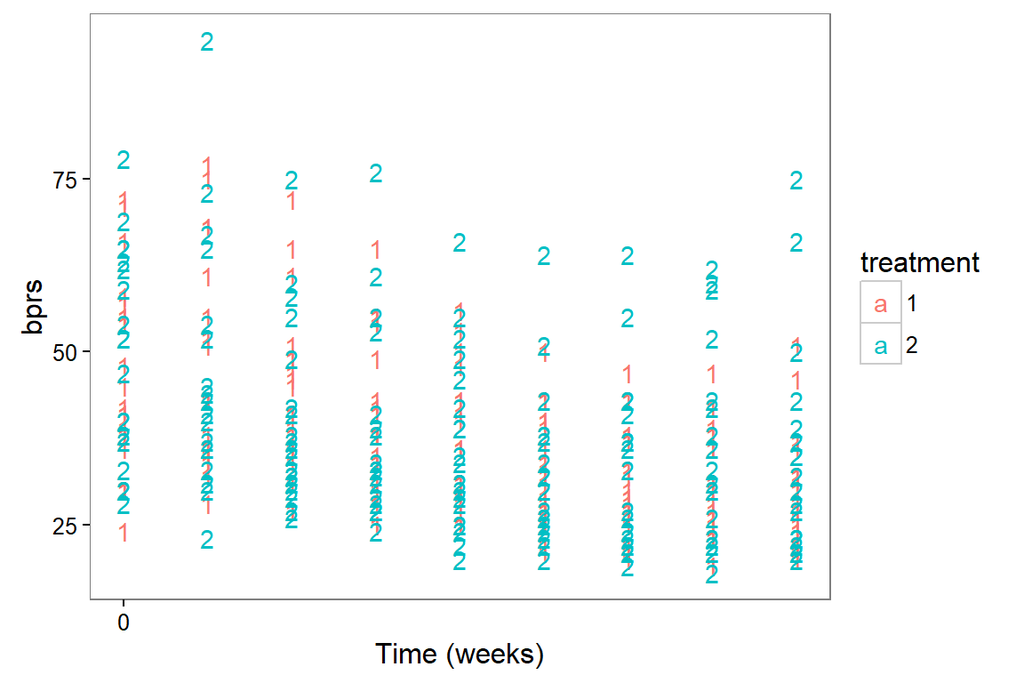

From this overview we can see that there is not much difference between treatment groups. Overall the bprs scores seem to go down slightly towards the end in the sense that there are more patients with lower scores. The patients with high baseline scores in group 1 seem to lose some of the symptoms towards the end, where as in group there are also patients with high scores during the last weeks, but it’s hard to say if these differences are statistically significant or just random.

### individual bprs profiles

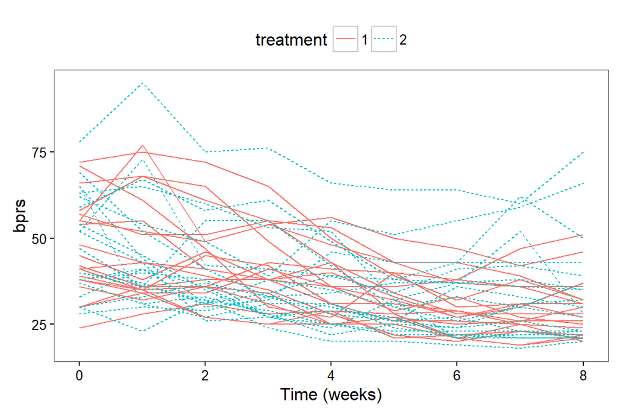

Here we can see the same trend as in the previous plot: In most cases the scores seem to slightly go down. This happens especially in the group 1, where as in group 2 there are some cases in where the scores start rising towards the end.

### Fitting a Linear Regression Model to BPRS data

```
##
## Call:
## lm(formula = bprs ~ week + treatment, data = BPRS)
##
## Residuals:
##     Min      1Q  Median      3Q     Max
## -22.454  -8.965  -3.196   7.002  50.244
##
## Coefficients:
##             Estimate Std. Error t value Pr(>|t|)
## (Intercept)  46.4539     1.3670  33.982   <2e-16 ***
## week         -2.2704     0.2524  -8.995   <2e-16 ***
## treatment2    0.5722     1.3034   0.439    0.661
## ---
## Signif. codes:  0 '***' 0.001 '**' 0.01 '*' 0.05 '.' 0.1 ' ' 1
##
## Residual standard error: 12.37 on 357 degrees of freedom
## Multiple R-squared:  0.1851, Adjusted R-squared:  0.1806
## F-statistic: 40.55 on 2 and 357 DF,  p-value: < 2.2e-16
```

In this model we have bprs score as the response variable and weeks and treatment as explanatory variables. It looks like treatment doesn’t have a significant effect on the bprs score, but time has a negative effect on the scores (scores drop as time passes, which is positive of course in this case).

Let’s skip the scatterplot, we already know that the bprs scores are not independent of each other over time.

```
## Linear mixed model fit by maximum likelihood  ['lmerMod']
## Formula: bprs ~ week + treatment + (1 | ind_subject)
##    Data: BPRS
##
##      AIC      BIC   logLik deviance df.resid
##   2582.9   2602.3  -1286.5   2572.9      355
##
## Scaled residuals:
##      Min       1Q   Median       3Q      Max
## -2.27506 -0.59909 -0.06104  0.44226  3.15835
##
## Random effects:
##  Groups      Name        Variance Std.Dev.
##  ind_subject (Intercept) 97.39    9.869
##  Residual                54.23    7.364
## Number of obs: 360, groups:  ind_subject, 40
##
## Fixed effects:
##             Estimate Std. Error t value
## (Intercept)  46.4539     2.3521  19.750
## week         -2.2704     0.1503 -15.104
## treatment2    0.5722     3.2159   0.178
##
## Correlation of Fixed Effects:
##            (Intr) week
## week       -0.256
## treatment2 -0.684  0.000
```

We can see that the standard error of time decreased. This is because the previous model ignored the dependencies between within subject measurements, increasing the standard error of within-subject covariates. In cotrast, the new model gives treatment a larger standard error.

That’s all for today, no time to do rest of the analysis..